# Data Mining Homework 1

Arman Zakaryan

September 30, 2017

### Problem 1

```r
load(file = 'Cars93.rda')
dim(df)
```

```
## [1] 93 28
```

## Problem 2

```r
head(df, n=5)
```

```
##   X Manufacturer   Model    Type Min.Price Price Max.Price MPG.city
## 1 1        Acura Integra   Small      12.9  15.9      18.8       25
## 2 2        Acura  Legend Midsize      29.2  33.9      38.7       18
## 3 3         Audi      90 Compact      25.9  29.1      32.3       20
## 4 4         Audi     100 Midsize      30.8  37.7      44.6       19
## 5 5          BMW    535i Midsize      23.7  30.0      36.2       22
##   MPG.highway            AirBags DriveTrain Cylinders EngineSize
## 1          31               None      Front         4        1.8
## 2          25 Driver & Passenger      Front         6        3.2
## 3          26        Driver only      Front         6        2.8
## 4          26 Driver & Passenger      Front         6        2.8
## 5          30        Driver only       Rear         4        3.5
##   Horsepower  RPM Rev.per.mile Man.trans.avail Fuel.tank.capacity
## 1        140 6300         2890             Yes               13.2
## 2        200 5500         2335             Yes               18.0
## 3        172 5500         2280             Yes               16.9
## 4        172 5500         2535             Yes               21.1
## 5        208 5700         2545             Yes               21.1
##   Passengers Length Wheelbase Width Turn.circle Rear.seat.room
## 1          5    177       102    68          37           26.5
## 2          5    195       115    71          38           30.0
## 3          5    180       102    67          37           28.0
## 4          6    193       106    70          37           31.0
## 5          4    186       109    69          39           27.0
##   Luggage.room Weight  Origin          Make
## 1           11   2705 non-USA Acura Integra
## 2           15   3560 non-USA  Acura Legend
## 3           14   3375 non-USA       Audi 90
## 4           17   3405 non-USA      Audi 100
## 5           13   3640 non-USA      BMW 535i
```

## Problem 3

```r
df[which.max(df$Max.Price),c(2,3)]
```

```
##     Manufacturer Model
## 59 Mercedes-Benz  300E
```

```r
df[which.min(df$Min.Price),c(2,3)]
```

```
##    Manufacturer Model
## 39          Geo Metro
```

## Problem 4

The class choice is not ideal, so we can change it to factor with the following layers:

```r
class(df$Origin)
```

```
## [1] "character"
```

```r
df$Origin <- factor(df$Origin,labels=c('non-USA','USA'))
head(df)
```

```
##   X Manufacturer   Model    Type Min.Price Price Max.Price MPG.city
## 1 1        Acura Integra   Small      12.9  15.9      18.8       25
## 2 2        Acura  Legend Midsize      29.2  33.9      38.7       18
## 3 3         Audi      90 Compact      25.9  29.1      32.3       20
## 4 4         Audi     100 Midsize      30.8  37.7      44.6       19
## 5 5          BMW    535i Midsize      23.7  30.0      36.2       22
## 6 6        Buick Century Midsize      14.2  15.7      17.3       22
##   MPG.highway            AirBags DriveTrain Cylinders EngineSize
## 1          31               None      Front         4        1.8
## 2          25 Driver & Passenger      Front         6        3.2
## 3          26        Driver only      Front         6        2.8
## 4          26 Driver & Passenger      Front         6        2.8
## 5          30        Driver only       Rear         4        3.5
## 6          31        Driver only      Front         4        2.2
##   Horsepower  RPM Rev.per.mile Man.trans.avail Fuel.tank.capacity
```

[output cut: 20 more lines]

```r
class(df$Origin)
```

```
## [1] "factor"
```

## Problem 5

```r
class(df$Type)
```

```
## [1] "factor"
```

```r
df$Type
```

```
##  [1] Small   Midsize Compact Midsize Midsize Midsize Large   Large
##  [9] Midsize Large   Midsize Compact Compact Sporty  Midsize Van
## [17] Van     Large   Sporty  Large   Compact Large   Small   Small
## [25] Compact Van     Midsize Sporty  Small   Large   Small   Small
## [33] Compact Sporty  Sporty  Van     Midsize Large   Small   Sporty
## [41] Sporty  Small   Compact Small   Small   Sporty  Midsize Midsize
## [49] Midsize Midsize Midsize Large   Small   Small   Compact Van
## [57] Sporty  Compact Midsize Sporty  Midsize Small   Midsize Small
## [65] Compact Van     Midsize Compact Midsize Van     Large   Sporty
## [73] Small   Compact Sporty  Midsize Large   Compact Small   Small
## [81] Small   Compact Small   Small   Sporty  Midsize Van     Small
## [89] Van     Compact Sporty  Compact Midsize
## Levels: Compact Large Midsize Small Sporty Van
```

## Problem 6

Here we observe a positive relationship

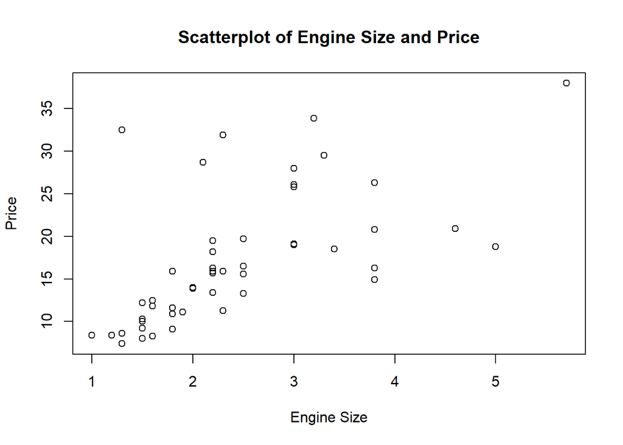

```r
set.seed(1)
df_small <- df[sample(nrow(df),50),]
plot(x=df_small$EngineSize, y=df_small$Price,
     main='Scatterplot of Engine Size and Price',
     xlab='Engine Size', ylab='Price')
```

## Problem 7

Here we see a negative relationship

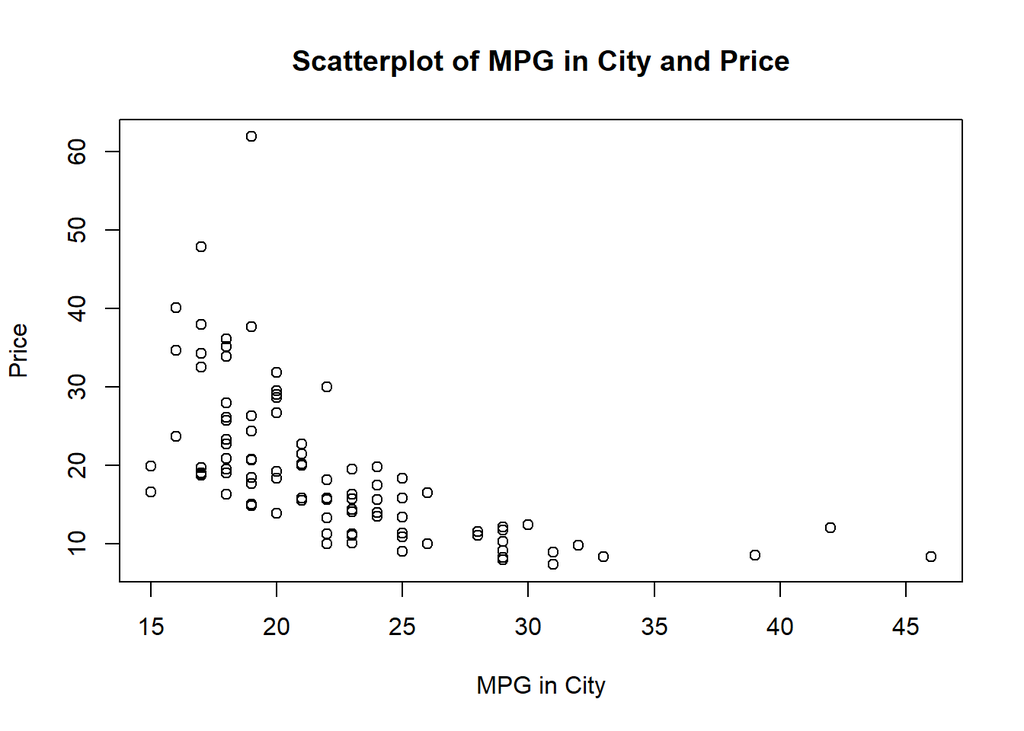

```r
plot(x=df$MPG.city, y=df$Price,
     main='Scatterplot of MPG in City and Price',
     xlab='MPG in City', ylab='Price')
```

## Problem 8

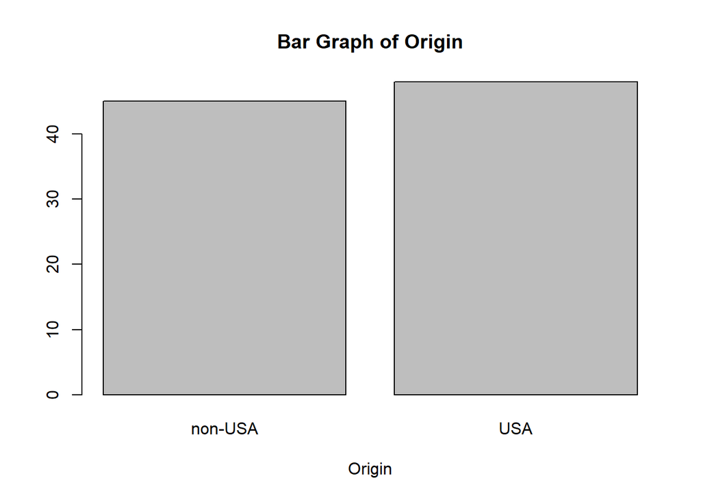

```r
plot(x=df$Origin,
     main='Bar Graph of Origin',
     xlab='Origin')
```

Slightly more USA cars.

## Problem 9

The most appropriate graph to represent the distribution is histogram. It shows the frequency of each range of values in the dataset. The higher “bars” rise, the higher is frequency.

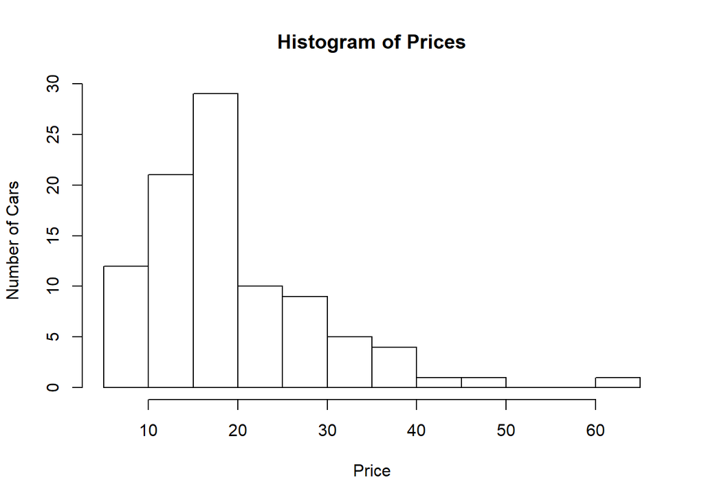

```r
hist(df$Price, main='Histogram of Prices', breaks=10,
     xlab='Price', ylab='Number of Cars')
```

## Problem 10

Boxplot is a good graph to explore the outliers. Any data point past whiskers will be considered an outlier.

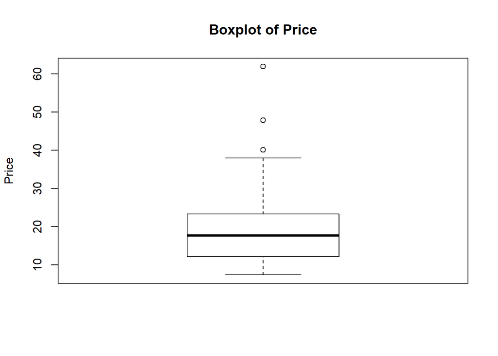

```r
boxpltres <- boxplot(df$Price, main='Boxplot of Price', ylab='Price')
```

```r
length(boxpltres$out)
```

```
## [1] 3
```

## Problem 11

```r
df <- df[df$Price>=boxpltres$stats[1] & df$Price<=boxpltres$stats[5],]
dim(df)
```

```
## [1] 90 28
```

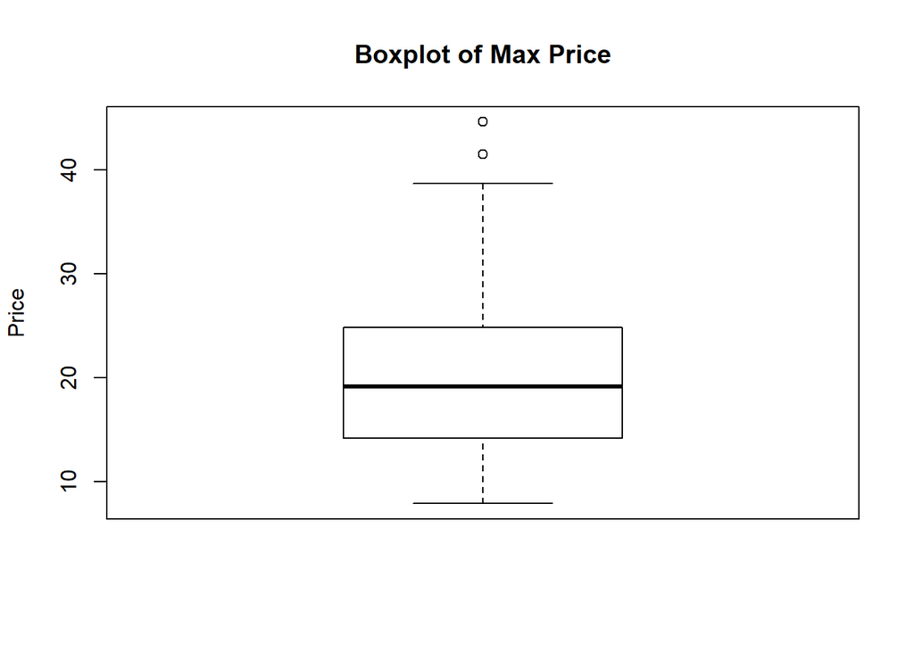

```r
boxpltres2 <- boxplot(df$Max.Price, main='Boxplot of Max Price', ylab='Price')
```

```r
df <- df[df$Max.Price>=boxpltres2$stats[1] & df$Max.Price<=boxpltres2$stats[5],]
dim(df)
```

```
## [1] 88 28
```

5 observations have been omitted, as they were outliers by either Price or Max.Price or both.

## Problem 12

```r
aggregate(df$Luggage.room~df$Manufacturer, data = df, mean)
```

```
##    df$Manufacturer df$Luggage.room
## 1            Acura        13.00000
## 2             Audi        14.00000
## 3              BMW        13.00000
## 4            Buick        17.00000
## 5         Cadillac        18.00000
## 6        Chevrolet        15.20000
## 7         Chrylser        15.00000
## 8         Chrysler        15.50000
## 9            Dodge        13.00000
## 10           Eagle        13.00000
## 11            Ford        15.14286
## 12             Geo        10.50000
## 13           Honda        11.33333
## 14         Hyundai        11.50000
```

[output cut: 17 more lines]

## Problem 13

```r
aggregate(df$Max.Price~df$Manufacturer, data=df, max)
```

```
##    df$Manufacturer df$Max.Price
## 1            Acura         38.7
## 2             Audi         32.3
## 3              BMW         36.2
## 4            Buick         26.3
## 5         Cadillac         36.3
## 6        Chevrolet         19.6
## 7         Chrylser         18.4
## 8         Chrysler         29.5
## 9            Dodge         33.1
## 10           Eagle         21.2
## 11            Ford         25.3
## 12             Geo         13.5
## 13           Honda         22.7
## 14         Hyundai         15.3
```

[output cut: 17 more lines]

## Problem 14

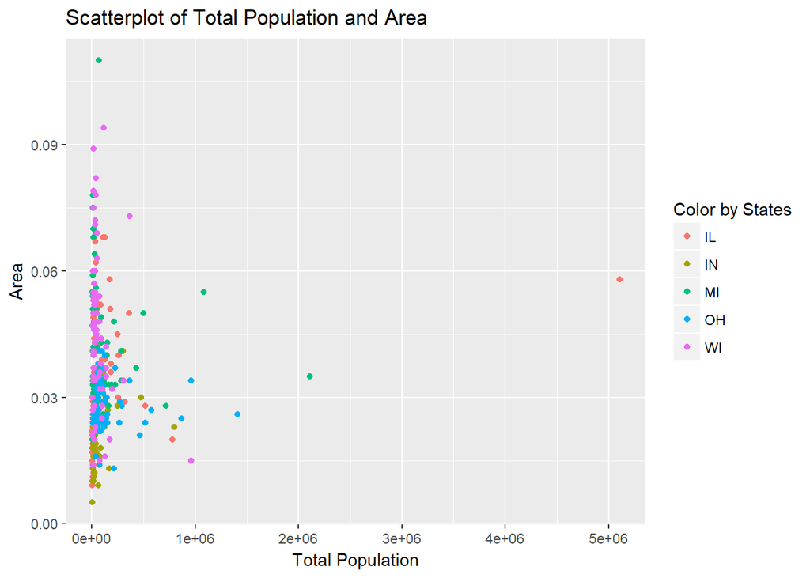

```r
library(ggplot2)
mymidwest <- midwest
p <- ggplot(mymidwest,aes(x=mymidwest$poptotal,
                     y=mymidwest$area, color=mymidwest$state))+
  geom_point()+
  labs(x='Total Population', y='Area',
       title = 'Scatterplot of Total Population and Area',
       color='Color by States')

p
```

## Problem 15

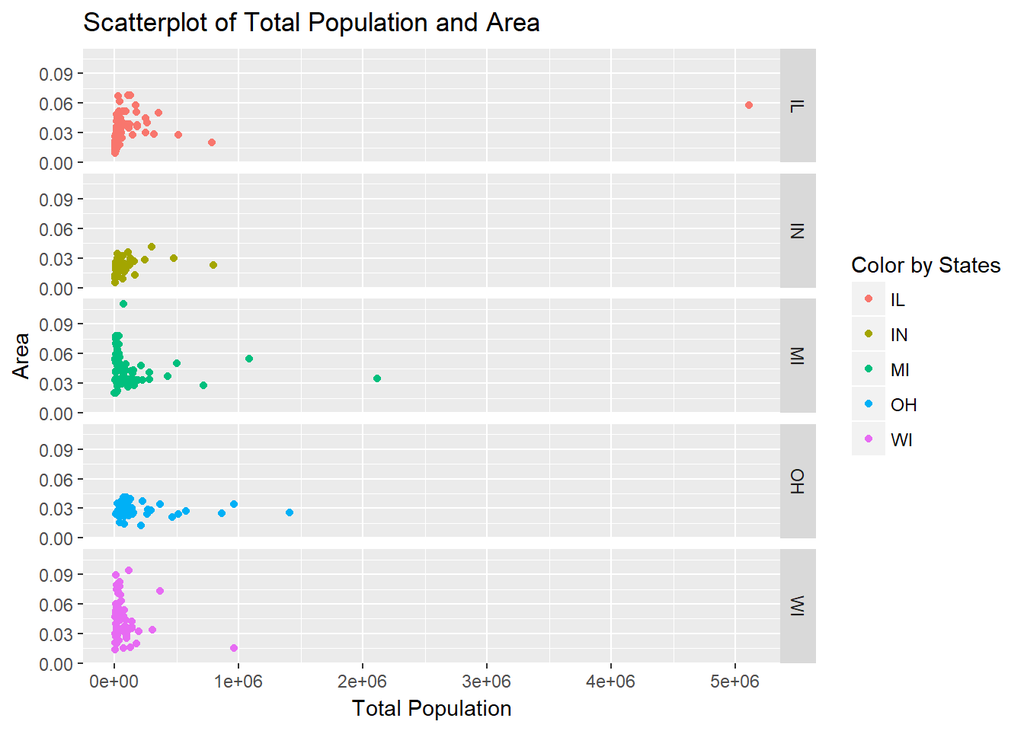

```r
p+facet_grid(mymidwest$state~.)
```

## Problem 16

Interesting finds: 1. Percentage of College Educated People is positively correlated with Perentage of people with Profession. 2. Percentage of Black people is positively correlated with percentage of people living below poverty.

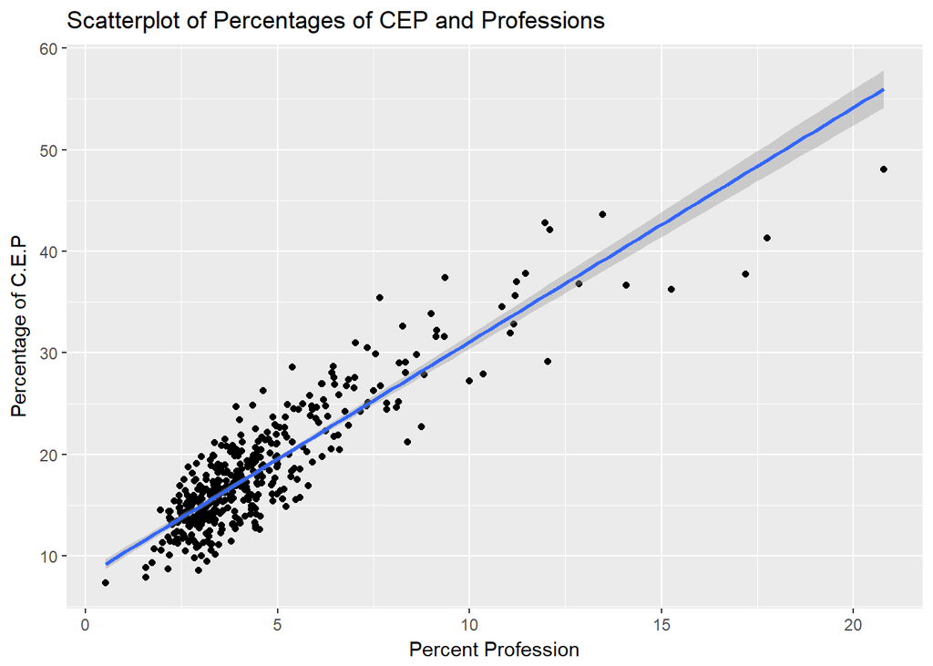

```r
ggplot(mymidwest,aes(x=mymidwest$percprof,
                     y=mymidwest$percollege))+
  geom_point()+geom_smooth(method = 'lm', na.rm=TRUE)+
  labs(x='Percent Profession', y='Percentage of C.E.P',
       title = 'Scatterplot of Percentages of CEP and Professions')
```

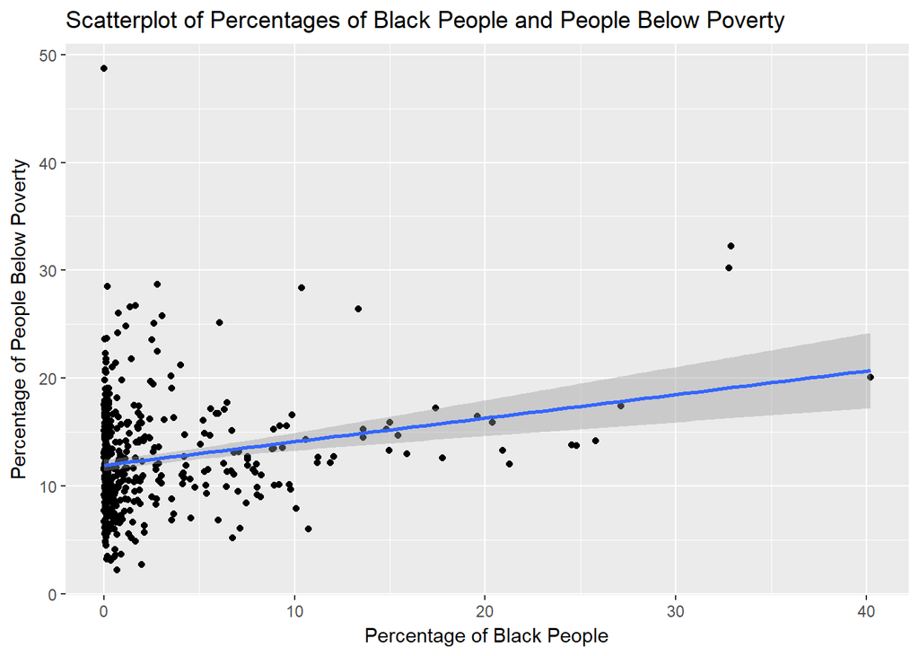

```r
ggplot(mymidwest,aes(x=mymidwest$percblack,
                     y=mymidwest$percbelowpoverty))+
  geom_point()+geom_smooth(method = 'lm', na.rm=TRUE)+
  labs(x='Percentage of Black People', y='Percentage of People Below Poverty',
       title = 'Scatterplot of Percentages of Black People and People Below Poverty')
```

The choice of both is intition and a little exploration of the Correlation Matrix.

## Problem 17

The graph below looks fuzzy, with a hint of negative relationship. Intuition would make me expect not-so-strong correlation, as in my opinion college provides enough background not to end up in poverty, but arguably not sufficient enough.

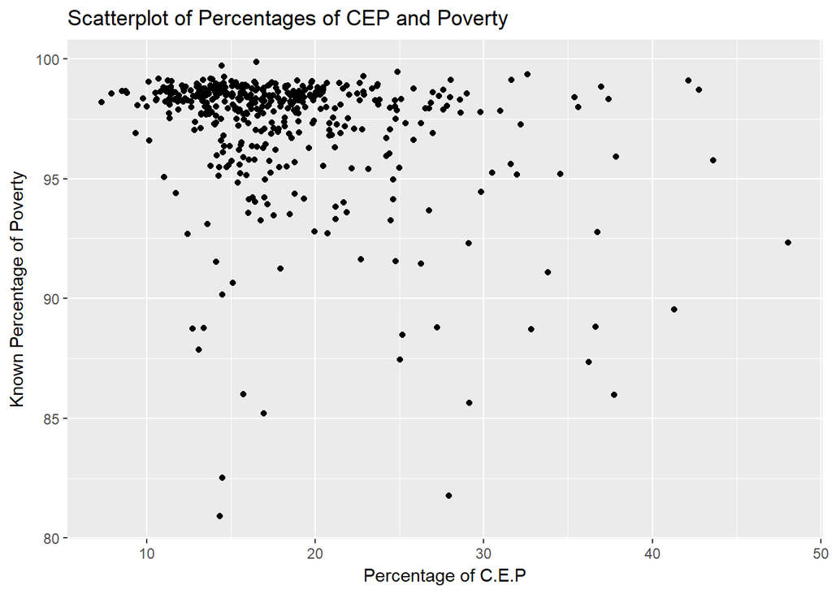

```r
ggplot(mymidwest,aes(x=mymidwest$percollege,
                     y=mymidwest$percpovertyknown))+
  geom_point()+
  labs(x='Percentage of C.E.P', y='Known Percentage of Poverty',
       title = 'Scatterplot of Percentages of CEP and Poverty')
```

## Problem 18

```r
cor(mymidwest$percollege, mymidwest$percpovertyknown)
```

```
## [1] -0.2661366
```

Yes!

## Problem 19

Signs show the nature of relationships between one another. Positive is the variables moving in one direction, negative means the opposite.

```r
num_midwest <- mymidwest[,4:13]
cor(num_midwest)
```

```
##                      area    poptotal  popdensity    popwhite    popblack
## area           1.00000000  0.06695501 -0.05897258  0.06690195  0.05318627
## poptotal       0.06695501  1.00000000  0.89783554  0.98911784  0.94689527
## popdensity    -0.05897258  0.89783554  1.00000000  0.91782159  0.82312485
## popwhite       0.06690195  0.98911784  0.91782159  1.00000000  0.89385103
## popblack       0.05318627  0.94689527  0.82312485  0.89385103  1.00000000
## popamerindian  0.18790586  0.81513642  0.79737626  0.81061165  0.78537728
## popasian       0.08131226  0.92308984  0.72569801  0.89457519  0.86359109
## popother       0.07738795  0.85783024  0.61373839  0.80602978  0.83823491
## percwhite     -0.04749440 -0.47527398 -0.52050948 -0.48125331 -0.46105397
## percblack     -0.04647417  0.55314701  0.63115802  0.56246120  0.54807945
##               popamerindian    popasian    popother  percwhite   percblack
## area              0.1879059  0.08131226  0.07738795 -0.0474944 -0.04647417
## poptotal          0.8151364  0.92308984  0.85783024 -0.4752740  0.55314701
## popdensity        0.7973763  0.72569801  0.61373839 -0.5205095  0.63115802
## popwhite          0.8106117  0.89457519  0.80602978 -0.4812533  0.56246120
## popblack          0.7853773  0.86359109  0.83823491 -0.4610540  0.54807945
## popamerindian     1.0000000  0.68358598  0.61427200 -0.6125700  0.51651506
## popasian          0.6835860  1.00000000  0.96333189 -0.3324405  0.34544994
## popother          0.6142720  0.96333189  1.00000000 -0.2842839  0.28699107
## percwhite        -0.6125700 -0.33244049 -0.28428390  1.0000000 -0.75958466
## percblack         0.5165151  0.34544994  0.28699107 -0.7595847  1.00000000
```

The most correlated ones are $poptotal$ and $popwhite$ (DUH).

## Problem 20

[figure not shown]

```r
library(corrplot)
midwestcor <- mymidwest[,c(-2,-3,-ncol(mymidwest))]
corrplot(cor(midwestcor), method = 'shade')
```